# Why use R?

## Outline

- Why use R?
- Examples
  - EDA
  - Plotting
  - Data manipulation
  - Reproducibility
- Advanced
  - Cloud computing
  - GIS
  - Web applications
- Compared to…

## Why use R?

- Because it can do more… but most of what I like are the advanced features.
- Data Exploration
- Plotting
- Reproducability
- Advanced features

  …but it can be a bit scary at the start.

## Exploratory Data Analysis - WIM

Weigh in Motion (WIM) data for a site in rural South Australia.

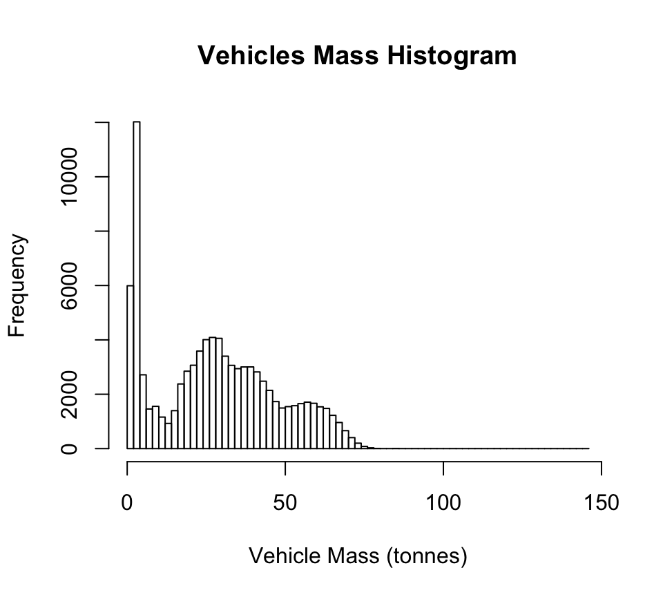

```r
wim <- read.csv("WiM_Formatted.csv")

names(wim)

hist(wim$GCM)

summary(wim$GCM)

wim[ wim$GCM > 100, "Config" ]
```

## Exploratory Data Analysis - WIM

Steer axle mass on 123 heavy vehicles can be used to determine if the site is measuring correctly.

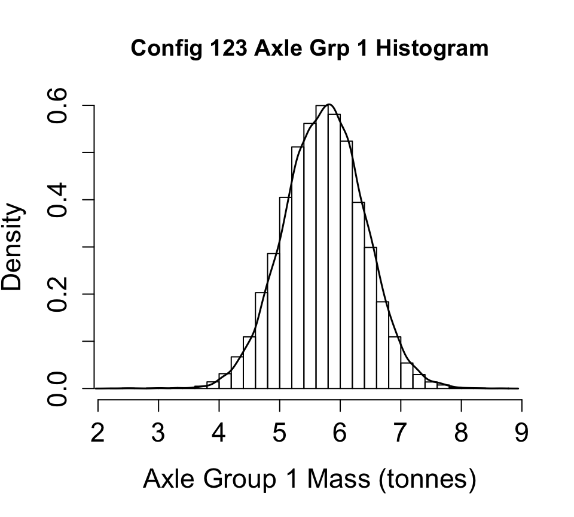

```r
Config123 <- wim[ wim$Config == 123, ]

hist(Config123$AXMASS1)
```

## EDA Plots - Iris

Tools for quick data overview and relationship between variables.

```
##   Sepal.Length    Sepal.Width
##  Min.   :4.300   Min.   :2.000
##  1st Qu.:5.100   1st Qu.:2.800
##  Median :5.800   Median :3.000
##  Mean   :5.843   Mean   :3.057
##  3rd Qu.:6.400   3rd Qu.:3.300
##  Max.   :7.900   Max.   :4.400
```

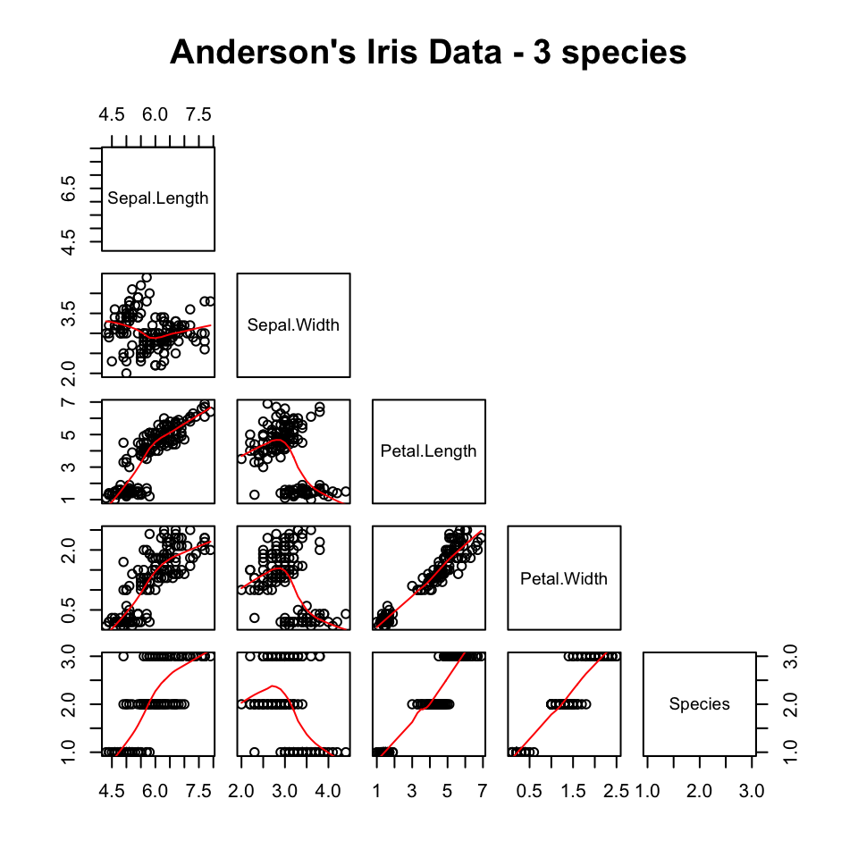

```r
summary(iris)

pairs(iris)
```

## Plotting - Cars

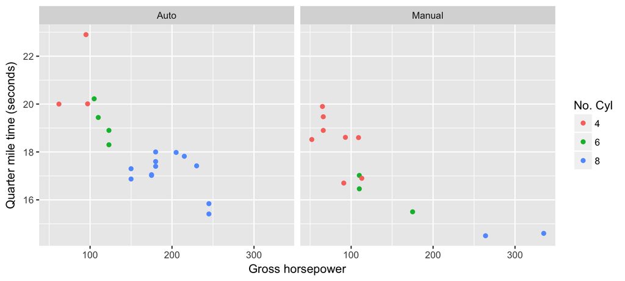

```r
library(ggplot2)

ggplot(mtcars, aes(x=hp, y=qsec, colour=as.factor(cyl))) +
    geom_point() +
    facet_wrap("am")
```

## Plotting - Themes

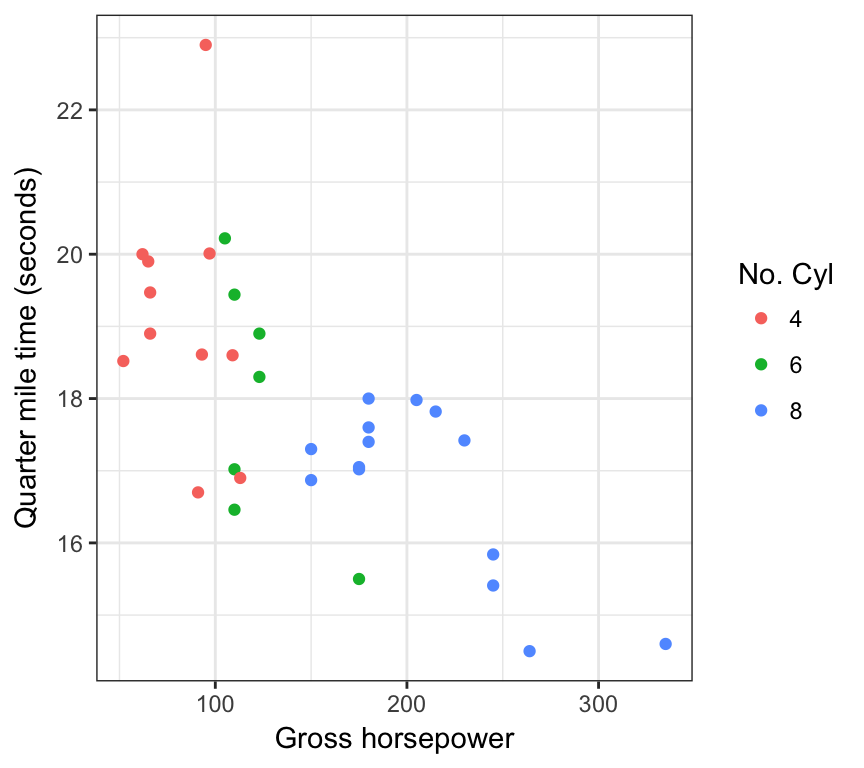

```r
g + theme_bw()
```

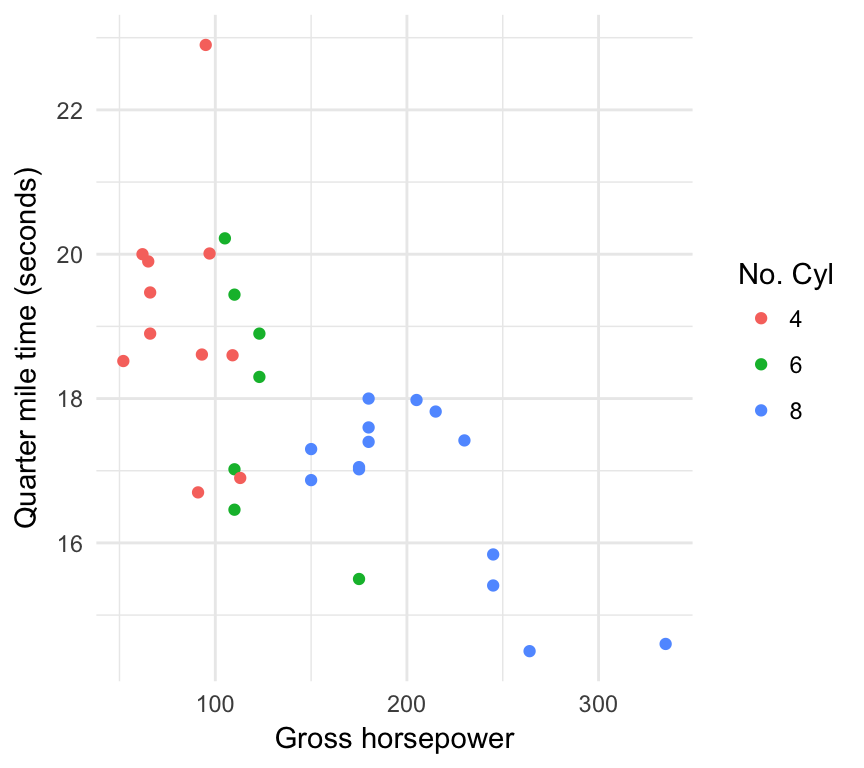

```r
g + theme_minimal()
```

## Plotting - More Themes

```r
library(ggthemes)
```

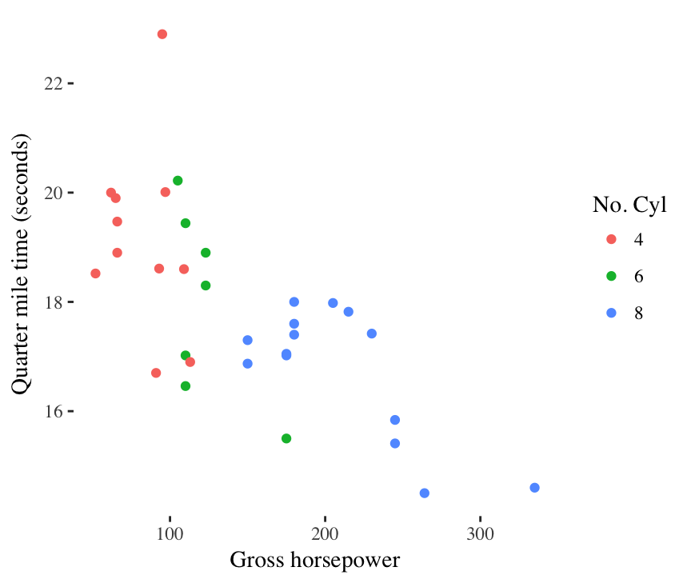

```r
g + theme_tufte()
```

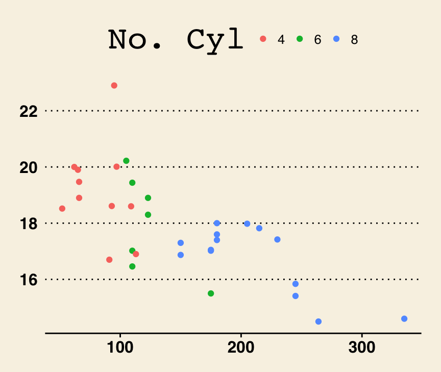

```r
g + theme_wsj()
```

## Plotting - Custom Graphics

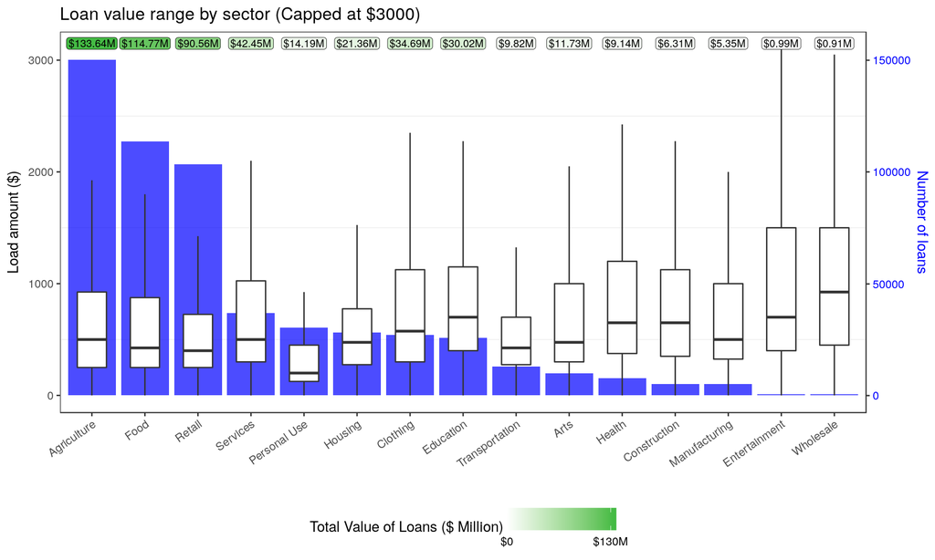

## New Plotting Package - ggpubr

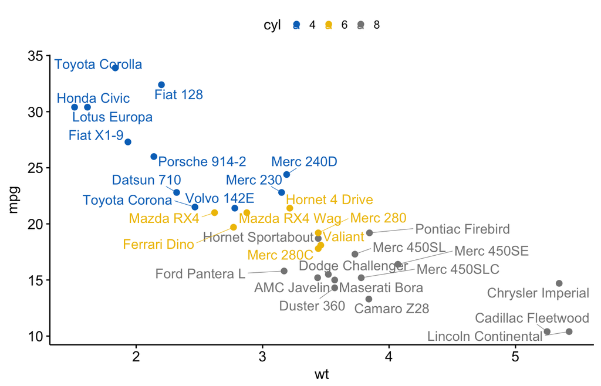

```r
library(ggpubr)

ggscatter(DF, x="wt", y="mpg", color="cyl", palette = "jco", label = "name", repel = TRUE)
```

## Data Manipulation

```r
# Subset / Filter
DF[DF$carb>=6,]

# Merge / Join
CYL_NM <- data.frame( cyl=c(4,6,8), cyl_nm=c("four", "six", "eight") )
merge( DF, CYL_NM, by="cyl" )

# Aggregate
aggregate( .~cyl, data=mtcars, FUN=mean )

# Loop
for( i in 1:5 ) { print( i ) }

# Function
fun1 <- function(x) { x^2 + 2*x + 4 }
fun1(5)
```

## Reproducability

Replication of experiments is the cornerstone of science, but replication isn't always possible. Reproducability ensures that data methodology of an analysis is record and can be tested.

Some ways to ensure reproducibility are:

- Scripting
- Incorporating instructions and explinations
- Providing data

## You can do more…

- Cloud computing
- GIS
  - Visualisation
  - Processing
- [Web applications](https://willhl.shinyapps.io/votemap/)

```r
leaflet(themeRegion) %>%
  addProviderTiles(providers$CartoDB.Positron) %>%
  setView( 18, 0, 2 ) %>%
  addHeatmap(lng = ~lon, lat = ~lat,
             intensity = ~number, blur=12,
             max = 1, radius = 10)
```

[interactive chart not shown]

## Comparison - strengths

**Excel**

- Data entry
- Looking at data values
- Works for small data
- Lower barrier of entry

**R**

- Visualisations
- Summaries
- Big datasets
- Reproducible resarch

**Tableau**

- Interactive visualisation
- Large datasets
- Ease of use

**Python**

- As per R
- Broader applications
- Slightly bigger learning curve

## Thanks!

Maps & Graphs - mapsgraphs.blogspot.com